# Credit Card Users Churn Prediction

## Data Pre-processing

We can drop column `CLIENTNUM` as this is unique id for the client

```python
# Dropping column - CLIENTNUM
df.drop(columns=["CLIENTNUM"], inplace=True)
```

### Replace missing value of Education_Level, Marital_Status and Income_Category missing with Unknown. Since these two columns are categorical column

```python
df['Education_Level']=df['Education_Level'].fillna('Unknown')
df['Marital_Status']=df['Marital_Status'].fillna('Unknown')
df.loc[df['Income_Category']=='abc','Income_Category']=np.nan
df['Income_Category'] = df['Income_Category'].fillna('Unknown')
```

### DataType conversion

`Attrition_Flag`, `Gender`, `Education_Level`, `Marital_Status`, `Income_Category` and `Card_Category` are categorical variables. Lets change the datatype to category

```python
df['Attrition_Flag'] = df['Attrition_Flag'].astype('category')
df['Gender'] = df['Gender'].astype('category')
df['Education_Level'] = df['Education_Level'].astype('category')
df['Marital_Status'] = df['Marital_Status'].astype('category')
df['Income_Category'] = df['Income_Category'].astype('category')
df['Card_Category'] = df['Card_Category'].astype('category')

##displaying dataframe details
df.info()
```

```
<class 'pandas.core.frame.DataFrame'>
RangeIndex: 10127 entries, 0 to 10126
Data columns (total 20 columns):
 #   Column                    Non-Null Count  Dtype
---  ------                    --------------  -----
 0   Attrition_Flag            10127 non-null  category
 1   Customer_Age              10127 non-null  int64
 2   Gender                    10127 non-null  category
 3   Dependent_count           10127 non-null  int64
 4   Education_Level           10127 non-null  category
 5   Marital_Status            10127 non-null  category
 6   Income_Category           10127 non-null  category
 7   Card_Category             10127 non-null  category
 8   Months_on_book            10127 non-null  int64
 9   Total_Relationship_Count  10127 non-null  int64
 10  Months_Inactive_12_mon    10127 non-null  int64
 11  Contacts_Count_12_mon     10127 non-null  int64
 12  Credit_Limit              10127 non-null  float64
 13  Total_Revolving_Bal       10127 non-null  int64
 14  Avg_Open_To_Buy           10127 non-null  float64
 15  Total_Amt_Chng_Q4_Q1      10127 non-null  float64
 16  Total_Trans_Amt           10127 non-null  int64
 17  Total_Trans_Ct            10127 non-null  int64
 18  Total_Ct_Chng_Q4_Q1       10127 non-null  float64
 19  Avg_Utilization_Ratio     10127 non-null  float64
dtypes: category(6), float64(5), int64(9)
memory usage: 1.1 MB
```

### Let's check the count of each unique category in each of the categorical variables.

```python
# Making a list of all categorical variables
cat_col = [
    "Attrition_Flag",
    "Gender",
    "Education_Level",
    "Marital_Status",
    "Income_Category",
    "Card_Category"
]

# Printing number of count of each unique value in each column
for column in cat_col:
    print(df[column].value_counts())
    print("-" * 40)
```

```
Existing Customer    8500
Attrited Customer    1627
Name: Attrition_Flag, dtype: int64
----------------------------------------
F    5358
M    4769
Name: Gender, dtype: int64
----------------------------------------
Graduate         3128
High School      2013
Unknown          1519
Uneducated       1487
College          1013
Post-Graduate     516
Doctorate         451
Name: Education_Level, dtype: int64
----------------------------------------
Married     4687
Single      3943
Unknown      749
Divorced     748
Name: Marital_Status, dtype: int64
----------------------------------------
Less than $40K    3561
$40K - $60K       1790
$80K - $120K      1535
$60K - $80K       1402
Unknown           1112
$120K +            727
Name: Income_Category, dtype: int64
----------------------------------------
Blue        9436
Silver       555
Gold         116
Platinum      20
Name: Card_Category, dtype: int64
----------------------------------------
```

### EDA & Data Visualization

```python
### Reuseable methods for drawing graphs

# Adds mean, median and mode line to the graph
def addGrapVLines(df, columnName,plot, title):
    plot.axvline(df[columnName].mean(), color='lightgreen', linestyle='-',linewidth=1)
    plot.axvline(df[columnName].median(), color='red', linestyle='--',linewidth=2)
    plot.axvline(df[columnName].mode()[0], color='orange', linestyle='-',linewidth=1)
    plot.legend({'Mean':df.mean(),'Median':df.median(),'Mode':df.mode()})
    plot.set(title=title)


# Draws three different types of graph (boxplot,distplot,violinplot) togather
def drawGraph(df,columnName):
    fig, axes = plt.subplots(ncols=3,figsize=(20, 5))


    plot=sns.boxplot(df[columnName],showmeans=True, data=df, ax=axes[0])
    addGrapVLines(df,columnName,plot,"df distribution and skewness for '"+columnName+"'")

    plot=sns.distplot(df[columnName],ax=axes[1],hist=True)
    addGrapVLines(df,columnName,plot," Variation in the df distribution for '"+columnName+"'")

    plot=sns.violinplot(df[columnName],showmeans=True,ax=axes[2])
    addGrapVLines(df,columnName,plot,"df Distribution for '"+columnName+"'")


# Draws Count plot for a particular column
def drawCountPlot(df,columnName,axes):
    dfPoints=df[columnName]
    indexCount = dfPoints.value_counts().index
    ax = sns.countplot(dfPoints, order=indexCount ,ax=axes)
    for patch in ax.patches:
        percentage = 100 * (patch.get_height()*1.0)/dfPoints.count()
        x = patch.get_x() + patch.get_width() / 2 - 0.05
        y = patch.get_y() + patch.get_height()
        ax.annotate("{percent:.2f}".format(percent=percentage)+"%", (x, y))
        ax.set_xticklabels(ax.get_xticklabels(), rotation=90)

# Draws two different types of graph (boxplot,distplot) with hue columntogather
def drawBiVariantGraph(df,columnName,hueColumn,ax):
    plot=sns.boxplot(data=df,y=columnName,x=hueColumn,hue=hueColumn, showmeans=True, ax=ax)
    plot.set(title="Data distribution and skewness\n for '"+columnName+"'")

#Draws boxplot for a given column using a given dataset
def drawBoxPlot(df,columnName,ax):
    plot=sns.boxplot(data=df,x=columnName, showmeans=True, ax=ax)
    plot.set(title="Data distribution and skewness\n for '"+columnName+"'")


def stacked_barplot(df, predictor, target):
    count = df[predictor].nunique()
    sorter = df[target].value_counts().index[-1]
    tab = pd.crosstab(data[predictor], data[target], normalize="index").sort_values(
        by=sorter, ascending=False
    )
    tab.plot(kind="bar", stacked=True, figsize=(count + 1, 5))
    plt.legend(
        loc="lower left",
        frameon=False,
    )
    plt.legend(loc="upper left", bbox_to_anchor=(1, 1))
    plt.show()
```

#### Univariate Analysis

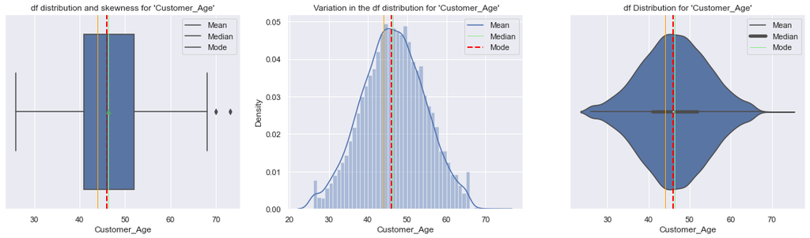

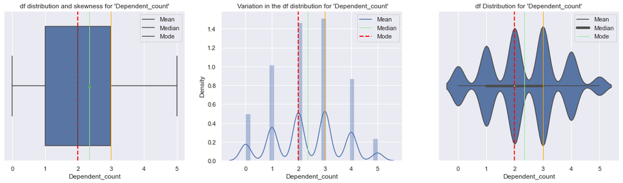

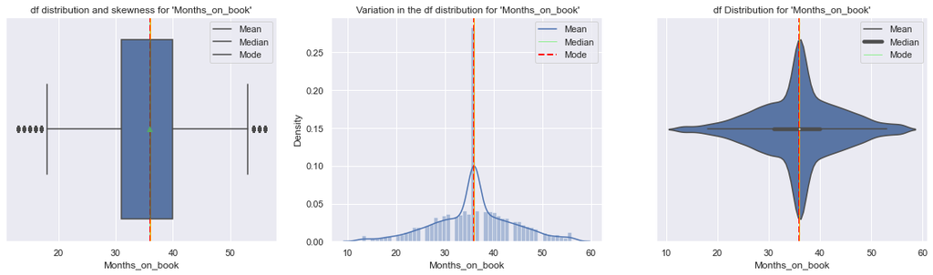

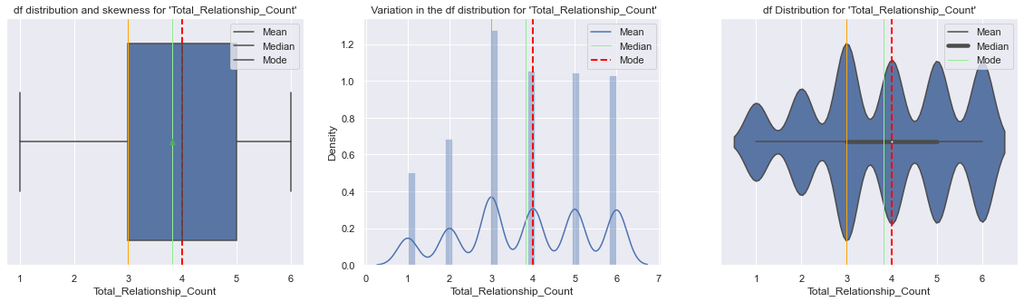

```python
drawGraph(df,'Customer_Age')
drawGraph(df,'Dependent_count')
drawGraph(df,'Months_on_book')
drawGraph(df,'Total_Relationship_Count')
```

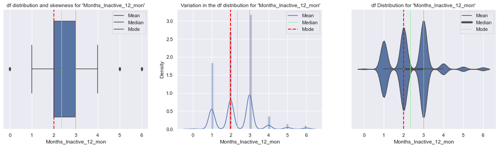

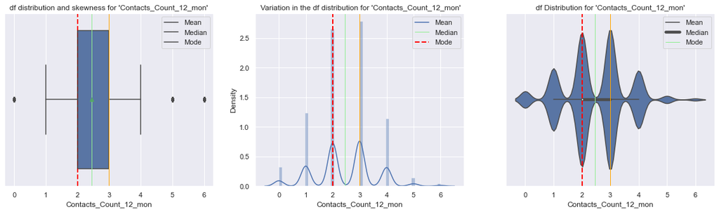

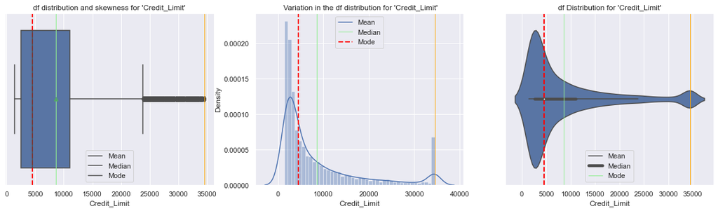

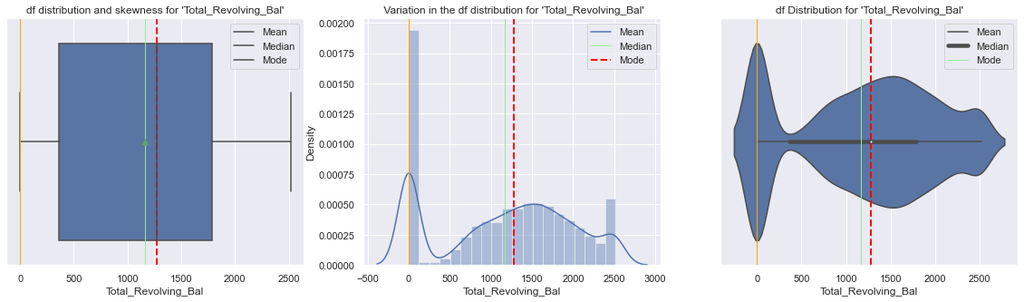

```python
drawGraph(df,'Months_Inactive_12_mon')
drawGraph(df,'Contacts_Count_12_mon')
drawGraph(df,'Credit_Limit')
drawGraph(df,'Total_Revolving_Bal')
```